# Homework 3

Please upload an html/pdf to Sakai by Wednesday, September 24, at 6 pm.

1. Use the below degrees of freedom and sums of squares from ANOVA tables from a multiple linear regression with three explanatory variables to answer the following questions.
- Model 1: $X_1$ as only explanatory variable

|  | df | Sums of Squares |
| --- | --- | --- |
| Model | 1 | 2469.18 |
| Error | 48 | 3766.14 |

- Model 2: $X_1$ and $X_2$ as explanatory variables

|  | df | Sums of Squares |
| --- | --- | --- |
| Model | 2 | 3647.83 |
| Error | 47 | 2587.49 |

- Model 3: $X_1$, $X_2$, and $X_3$ as explanatory variables

|  | df | Sums of Squares |
| --- | --- | --- |
| Model | 3 | 4348.22 |
| Error | 46 | 1887.10 |

1. What are the total sums of squares and the sample variance of the response variable?

```r
dfm1 <- 1
dfe1 <- 48
ssm1 <- 2469.18
sse1 <- 3766.14

# calculate sst and dftotal
sst <- ssm1 + sse1
sst
```

```
[1] 6235.32
```

```r
dft <- dfe1 + dfm1

# find the sample variance
s_y2 <- sst/dft
s_y2
```

```
[1] 127.2514
```

2. What are the additional model sums of squares when we add $X_2$ and $X_3$ to a model that includes $X_1$?

   The additional model sums of squares when we add x2 and x3 to a model that includes x1 are 1178.65 when we add x2 and 700.39 when we add x2 and x3. Together they add 1879.04 to the model.

```r
ssm1 <- 2469.18
ssm2 <- 3647.83
ssm3 <- 4348.22

#find additional ss
ss_x2_given_x1 <- ssm2 - ssm1
ss_x3_given_x1x2 <- ssm3 - ssm2

ss_x2_given_x1
```

```
[1] 1178.65
```

```r
ss_x3_given_x1x2
```

```
[1] 700.39
```

```r
total_additional_ssm <- ss_x2_given_x1 + ss_x3_given_x1x2

total_additional_ssm
```

```
[1] 1879.04
```

3. What is additional percent variation in the response variable can be explained when we add $X_3$ to a model that already includes $X_1$ and $X_2$?

   the additional percent variation in the response variable that can be explained when we add x3 to a model that already includes x1 and x2 is 11.23%

```r
(ss_x3_given_x1x2/sst) * 100
```

```
[1] 11.23262
```

4. What is the mean squared error for the linear model with $X_1$ and $X_2$ as explanatory variables?\

   $MSE_{x1x2} = 55.05$

```r
sse2 <- 2587.49
dfe2 <- 47
mse2 <- sse2/dfe2
mse2
```

```
[1] 55.05298
```

5. Find an F statistic and p-value for testing for overall significance of the linear model with $X_1$, $X_2$, and $X_3$ as explanatory variables.

   $F = 35.33 , p = 5.339x10^{-12}$

```r
sse3 <- 1887.10
dfm3 <- 3
dfe3 <- 46

msm3 <- ssm3 / dfm3
mse3 <- sse3 / dfe3
f3 <- msm3 / mse3
f3
```

```
[1] 35.33078
```

```r
pvalue3 <- 1 - pf(f3,dfm3,dfe3)
pvalue3
```

```
[1] 5.338618e-12
```

6. Find an F statistic and p-value for testing if adding $X_3$ to a linear model that already includes $X_1$ and $X_2$ is statistically significant.

   $F = 17.07, p = 1.504x10^{-4}$

```r
dfm2 <- 2
dfx3 <- dfm3 - dfm2
Fx3 <- (ss_x3_given_x1x2/dfx3) / (sse3/dfe3)
Fx3
```

```
[1] 17.07273
```

```r
pvaluex3 <- 1 - pf(Fx3,dfx3,dfe3)
pvaluex3
```

```
[1] 0.0001504192
```

2. Consider the dataset realestate.csv, a dataset on real estate sales in New Taipei City, which contains the following variables:
- Age: The age of the house in years
- MRT: The distance in meters to the nearest public transportation station
- Convenience: The amount of convenience stores within one kilometer of the house
- Latitude: The degrees north latitude of the house
- Longitude: The degrees east longitude of the house
- Price: The house sales price in millions of New Taiwan Dollars
1. Suppose we create a linear model with house price as the response variable and all of the other variables in the dataset as the explanatory variables. Perform an overall F test to determine if this overall linear model is statistically significant. Be sure to include all necessary information to perform a hypothesis test. Assume $\alpha = 0.05$.

   $H_0: B_j = 0: j = 1...6$ , $H_a: \exists B_j \neq 0: j = 1…6$

   $F = 108.7 p < 2.2e-16$ , we can reject the null and conclude the overall linear model using house price as the response variable and age of the house, distance in meters to the nearest public transportation station, the amount of convenience stores within one kilometer of the house, the degrees north of latitude of the house, and the degrees east of longitude of the house as explanatory variables is statistically significant.

```r
library(readr)
realestate <- read_csv("~/stat408/Homework3/Data/realestate.csv")
mod <- lm(Price ~ ., realestate)
summary(mod)
```

```
Call:
lm(formula = Price ~ ., data = realestate)

Residuals:
    Min      1Q  Median      3Q     Max
-34.546  -5.267  -1.600   4.247  76.372

Coefficients:
              Estimate Std. Error t value Pr(>|t|)
(Intercept) -4.946e+03  6.211e+03  -0.796    0.426
Age         -2.689e-01  3.900e-02  -6.896 2.04e-11 ***
MRT         -4.259e-03  7.233e-04  -5.888 8.17e-09 ***
Convenience  1.163e+00  1.902e-01   6.114 2.27e-09 ***
Latitude     2.378e+02  4.495e+01   5.290 2.00e-07 ***
Longitude   -7.805e+00  4.915e+01  -0.159    0.874
---
Signif. codes:  0 '***' 0.001 '**' 0.01 '*' 0.05 '.' 0.1 ' ' 1

Residual standard error: 8.965 on 408 degrees of freedom
Multiple R-squared:  0.5712,    Adjusted R-squared:  0.5659
F-statistic: 108.7 on 5 and 408 DF,  p-value: < 2.2e-16
```

2. Check if the assumptions of homoscedasticity and normally distributed residuals are violated for the model in (a).

   While the residual plot shows signs of heteroscedasticity, the Breusch-Pagan test resulted in a pvalue larger than .05, according to these results homoscedasticity would not be violated.

   However, the Q-Q plot shows deviations on one end of the plot and the Kolmogrov-Smirnov test resulted in a pvalue less than .05, and we can conclude the assumption of normally distributed results is violated.

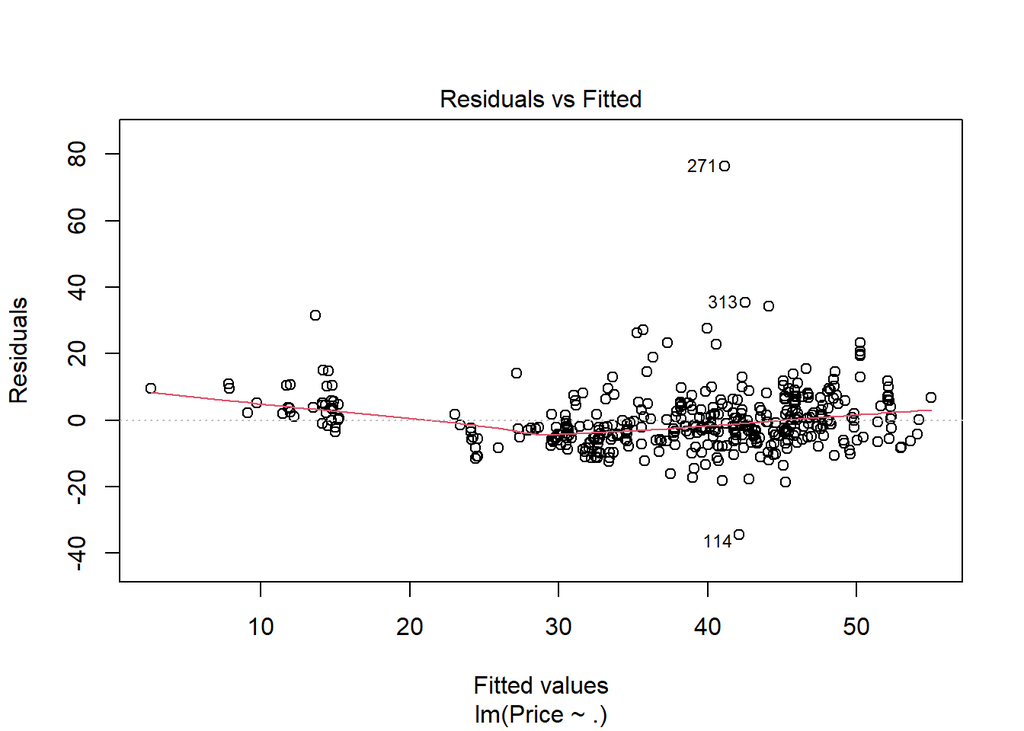

```r
#homoscedasticity
plot(mod,1)
```

```r
library(lmtest)
bptest(mod)
```

```
    studentized Breusch-Pagan test

data:  mod
BP = 4.4956, df = 5, p-value = 0.4805
```

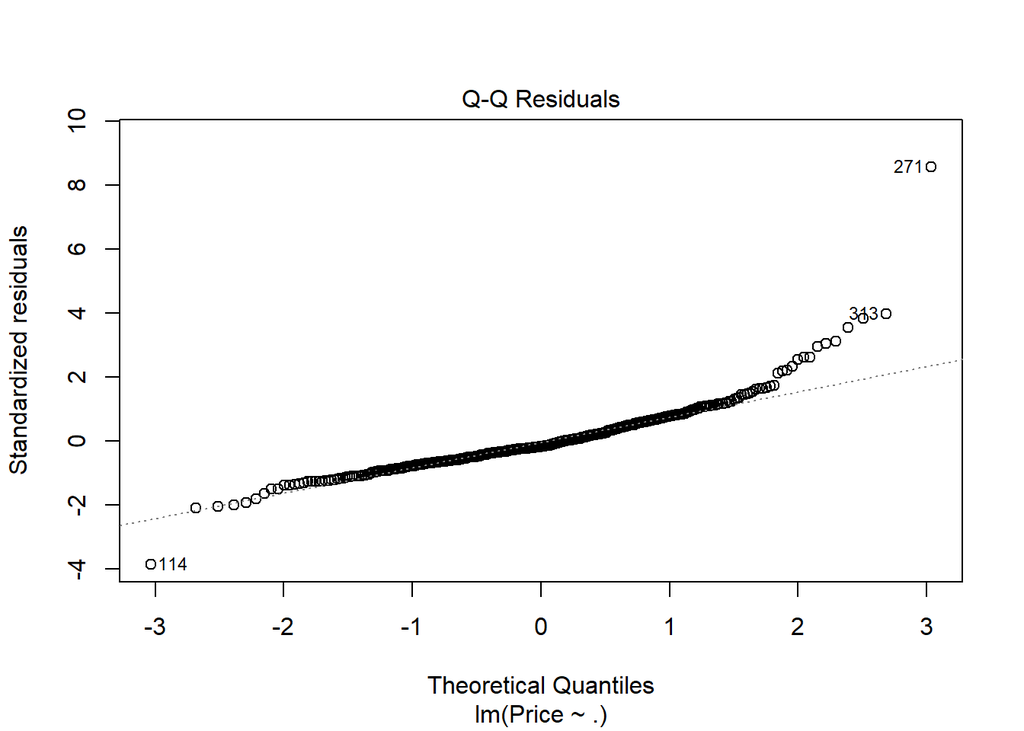

```r
#normality
plot(mod,2)
```

```r
ks.test(rstandard(mod), "pnorm")
```

```
    Asymptotic one-sample Kolmogorov-Smirnov test

data:  rstandard(mod)
D = 0.091702, p-value = 0.001893
alternative hypothesis: two-sided
```

3. Report and interpret the $r^2$ for the overall linear model in the context of the problem.

   $r^2 = 0.5712$ , The model explains 57.12% of the variability in sales based on the predictors (Age, MRT, Convenience, Longitude, Latitude) included in the model. This indicates that the predictors are strongly associated with the outcome, although 42.88% of the variability remains unexplained by the model.

```r
summary(mod)$r.squared
```

```
[1] 0.5711617
```

4. Suppose we know that sales price is linearly related with age of the house.

(i). Perform a hypothesis test to determine if adding at least one other variable to our linear model significantly improves the predictive ability of our model. Be sure to include all necessary information to perform a hypothesis test. Assume $\alpha = 0.05$.

$H_0: \beta_j = 0: j = 2 … 6 , H_a: \exists \beta_j \neq 0: j = 2 … 6$

$F = 125.31 , p < 2.2e-16$ , therefore we reject the null and can conclude that adding at least one other variable to our linear model relating price to age of the house significantly improves the predictive ability of our model.

```r
mod_red <- lm(Price ~ Age, realestate)
mod_full <- lm(Price ~ ., realestate)
anova(mod_red,mod_full)
```

```
Analysis of Variance Table

Model 1: Price ~ Age
Model 2: Price ~ Age + MRT + Convenience + Latitude + Longitude
  Res.Df   RSS Df Sum of Sq      F    Pr(>F)
1    412 73071
2    408 32790  4     40282 125.31 < 2.2e-16 ***
---
Signif. codes:  0 '***' 0.001 '**' 0.01 '*' 0.05 '.' 0.1 ' ' 1
```

(ii). Perform a hypothesis test to determine if adding amount of convenience stores to our linear model that already includes age of the house significantly improves the predictive ability of our model. Be sure to include all necessary information to perform a hypothesis test. Assume $\alpha = 0.05$.

$F = 225.85, p < 2.2e-16$ therefore we can reject the null hypothesis and conclude that adding the amount of convenience stores within one kilometer of the house as an explanatory variable to a linear model that already includes age of the house as an explanatory variable significantly improves the predictive ability of our model.

```r
mod_full2 <- lm(Price ~ Age + Convenience, realestate)
anova(mod_red, mod_full2)
```

```
Analysis of Variance Table

Model 1: Price ~ Age
Model 2: Price ~ Age + Convenience
  Res.Df   RSS Df Sum of Sq      F    Pr(>F)
1    412 73071
2    411 47157  1     25914 225.85 < 2.2e-16 ***
---
Signif. codes:  0 '***' 0.001 '**' 0.01 '*' 0.05 '.' 0.1 ' ' 1
```

(iii). What is the additional percent variation in sales price of houses in New Taipei City than can be explained by adding *only* amount of convenience stores to our linear model that already includes age of the house.

The additional percent variation in sales price of houses in New Taipei City that can be explained by adding only amount of convenience stores within one kilometer of the house as an explanatory variable to our linear model that already includes age of the house as an explanatory variable is $33.89\%$

Meaning that when we add the number of convenience stores within one kilometer as an explanatory variable to a model that already includes the age of the house as an explanatory variable, the model’s explanatory power increases substantially (33.89%). This suggests that proximity to a convenience store is a strong predictor of housing prices in New Taipei City, in fact the model that includes both age and convenience store count can explain about a third more of the variation in housing prices alone.

```r
mod_red_r2 <- summary(mod_red)$r.squared
mod_full2_r2 <- summary(mod_full2)$r.squared
add_var <- mod_full2_r2 - mod_red_r2
add_percent_var <- add_var * 100
add_percent_var
```

```
[1] 33.89147
```